# splineplot

### Logistic regression with natural splines

[output not shown]

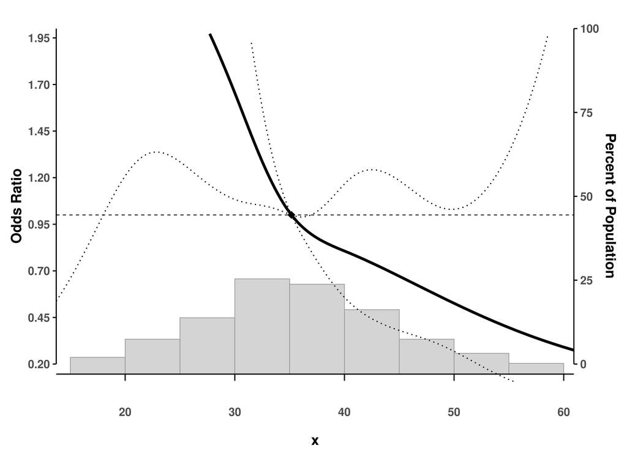

```r
# Fit logistic model with natural splines
fit_glm <- glm(binary_y ~ ns(x, df = 4),
               family = binomial(), data = dat)

# Create spline plot
splineplot(fit_glm, dat,
          ylim = c(0.2, 2.0),
          ylab = "Odds Ratio")
```

### GAM with interaction terms

[output not shown]

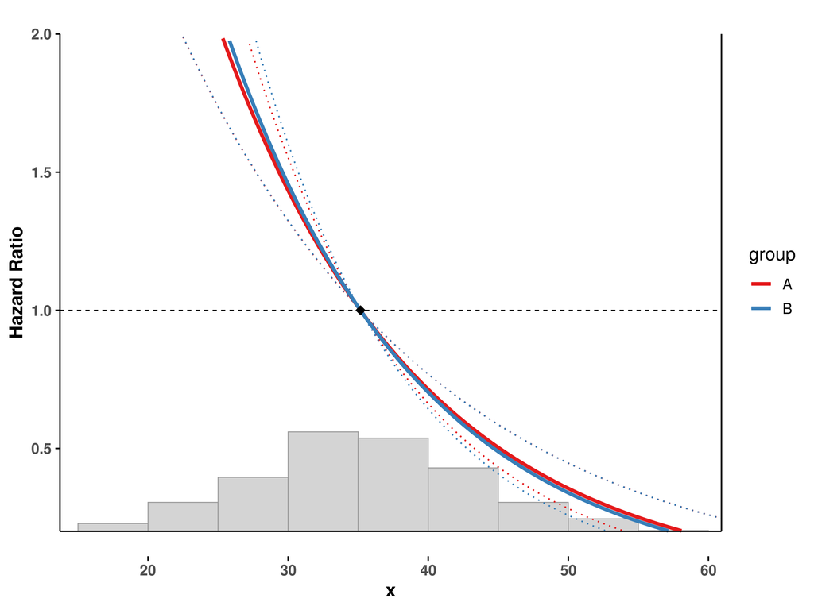

```r
# Add a grouping variable
dat$group <- factor(sample(c("A", "B"), n, replace = TRUE))

# Fit model with interaction
fit_interaction <- gam(Surv(time, status) ~ s(x, by = group),
                      family = cox.ph(), data = dat)

# Plot with interaction
splineplot(fit_interaction, dat,
          ylim = c(0.2, 2.0))
```

## Advanced Features

### Customizing confidence intervals

```r
# Default: dotted lines
splineplot(fit_gam_cox, dat, ribbon_ci = FALSE)

# Alternative: ribbon/shaded area
splineplot(fit_gam_cox, dat, ribbon_ci = TRUE)
```

### Log scale for odds/rate/hazard ratios

[output not shown]

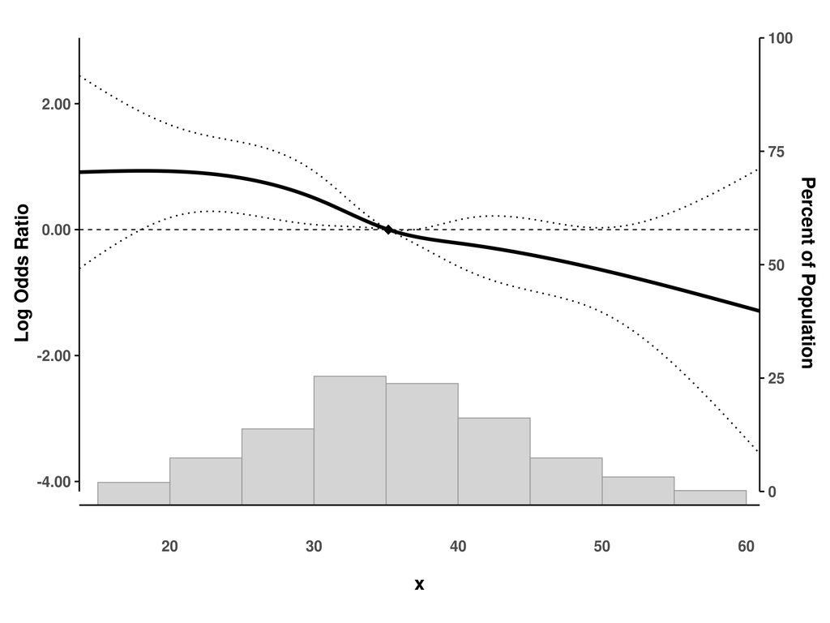

```r
# Use log scale for y-axis
splineplot(fit_glm, dat, log_scale = TRUE)
```

### Custom reference values

[output not shown]

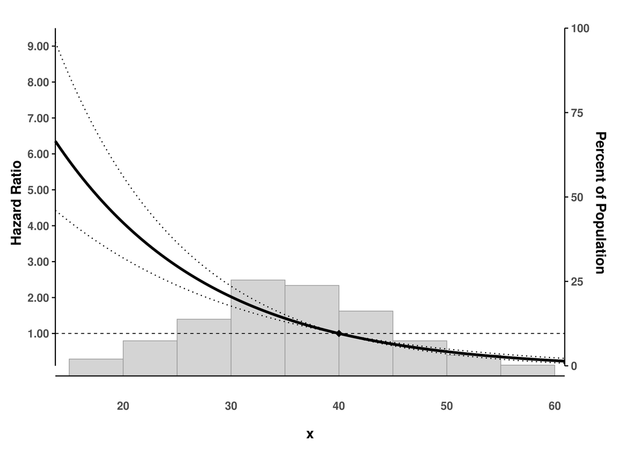

```r
# Set custom reference point (default is median)
splineplot(fit_gam_cox, dat,
          refx = 40,  # Reference at x = 40
          show_ref_point = TRUE)  # Show diamond marker
```

## Supported Model Types

| Model Type | Model Function | Spline Types | Outcome |
| --- | --- | --- | --- |
| GAM | `mgcv::gam()` | `s()`, `te()`, `ti()` | HR, OR, RR, Effect |
| GLM | `stats::glm()` | `ns()`, `bs()` | OR, RR, Effect |
| Linear | `stats::lm()` | `ns()`, `bs()` | Effect |
| Cox | `survival::coxph()` | `ns()`, `bs()`, `pspline()`* | HR |

*Note: `pspline()` has limited support due to its internal structure. We recommend using `ns()` or `bs()` with Cox models for optimal results.

## Function Parameters

| Parameter | Description | Default |
| --- | --- | --- |
| `fit` | Fitted model object | Required |
| `data` | Data frame used for fitting | Required |
| `xvar` | Variable name for x-axis | Auto-detected |
| `by_var` | Interaction variable | Auto-detected |
| `refx` | Reference x value | Median of x |
| `xlim` | X-axis limits | Data range |
| `ylim` | Y-axis limits | Auto |
| `show_hist` | Show histogram | TRUE |
| `ribbon_ci` | Use ribbon CI style | FALSE |
| `log_scale` | Use log scale for y-axis | FALSE |
| `show_ref_point` | Show reference point marker | TRUE |
| `xlab` | X-axis label | Variable name |
| `ylab` | Y-axis label | Auto by model |
| `ylab_right` | Right y-axis label | “Percent of Population” |

## Citation

If you use splineplot in your research, please cite:

```r
citation("splineplot")
```

## Getting Help

- **Documentation**: Visit our [pkgdown site](https://jinseob2kim.github.io/splineplot/)
- **Bug reports**: [GitHub Issues](https://github.com/jinseob2kim/splineplot/issues)
- **Questions**: [GitHub Discussions](https://github.com/jinseob2kim/splineplot/discussions)

## Contributing

Contributions are welcome! Please feel free to submit a Pull Request. For major changes, please open an issue first to discuss what you would like to change.

## License

Apache License 2.0 © Jinseob Kim / Zarathu - see the LICENSE file for details.

## Acknowledgments

Special thanks to the developers of mgcv, survival, and ggplot2 packages.